# Tidyverse Sample Exam v2.0

## Tidyverse Exam

### Basic Operations

1. Read the file `person.csv` and store the result in a tibble called `person`.

```r
person <- readr::read_csv("https://education.rstudio.com/blog/2020/08/more-example-exams/person.csv")
```

2. Create a tibble containing only family and personal names, in that order. You do not need to assign this tibble or any others to variables unless explicitly asked to do so. However, as noted in the introduction, you *must* use the pipe operator `%>%` and code that follows the tidyverse style guide.

```r
person |> dplyr::select(family_name, personal_name)
```

```
## # A tibble: 5 x 2
##   family_name personal_name
##   <chr>       <chr>
## 1 Dyer        William
## 2 Pabodie     Frank
## 3 Lake        Anderson
## 4 Roerich     Valentina
## 5 Danforth    Frank
```

3. Create a new tibble containing only the rows in which family names come *before* the letter `M`. Your solution should work for tables with more rows than the example, i.e., you cannot rely on row numbers or select specific names.

```r
seq <- letters[which(letters == "a"):which(letters == "m") - 1]

person |>
  dplyr::filter(tolower(stringr::str_sub(family_name, end = 1)) %in% seq)
```

```
## # A tibble: 3 x 3
##   person_id personal_name family_name
##   <chr>     <chr>         <chr>
## 1 dyer      William       Dyer
## 2 lake      Anderson      Lake
## 3 danforth  Frank         Danforth
```

4. Display all the rows in `person` sorted by family name length with the longest name first.

```r
person |>
  dplyr::arrange(desc(
    nchar(family_name)
  ))
```

```
## # A tibble: 5 x 3
##   person_id personal_name family_name
##   <chr>     <chr>         <chr>
## 1 danforth  Frank         Danforth
## 2 pb        Frank         Pabodie
## 3 roe       Valentina     Roerich
## 4 dyer      William       Dyer
## 5 lake      Anderson      Lake
```

### Cleaning and Counting

1. Read the file `measurements.csv` to create a tibble called `measurements`. (The strings `"rad"`, `"sal"`, and `"temp"` in the `quantity` column stand for “radiation”, “salinity”, and “temperature” respectively.)

```r
measurements <- readr::read_csv("https://education.rstudio.com/blog/2020/08/more-example-exams/measurements.csv")
```

2. Create a tibble containing only rows where *none* of the values are `NA` and save in a tibble called `cleaned`.

```r
cleaned <- measurements |> tidyr::drop_na()
```

3. Count the number of measurements of each type of quantity in `cleaned`. Your result should have one row for each quantity `"rad"`, `"sal"`, and `"temp"`.

```r
cleaned |>
  dplyr::count(quantity)
```

```
## # A tibble: 3 x 2
##   quantity     n
##   <chr>    <int>
## 1 rad          8
## 2 sal          7
## 3 temp         3
```

4. Display the minimum and maximum value of `reading` separately for each quantity in `cleaned`. Your result should have one row for each quantity `"rad"`, `"sal"`, and `"temp"`.

```r
cleaned |>
  dplyr::group_by(quantity) |>
  dplyr::summarise(min = min(reading),
                   max = max(reading))
```

```
## # A tibble: 3 x 3
##   quantity    min   max
##   <chr>     <dbl> <dbl>
## 1 rad        1.46  11.2
## 2 sal        0.05  41.6
## 3 temp     -21.5  -16
```

5. Create a tibble in which all salinity (`"sal"`) readings greater than 1 are divided by 100. (This is needed because some people wrote percentages as numbers from 0.0 to 1.0, but others wrote them as 0.0 to 100.0.)

```r
cleaned |>
  dplyr::mutate(reading = dplyr::case_when(
    quantity == "sal" & reading > 1 ~ reading/100,
    TRUE ~ reading
  ))
```

```
## # A tibble: 18 x 4
##    visit_id visitor quantity reading
##       <dbl> <chr>   <chr>      <dbl>
##  1      619 dyer    rad        9.82
##  2      619 dyer    sal        0.13
##  3      622 dyer    rad        7.8
##  4      622 dyer    sal        0.09
##  5      734 pb      rad        8.41
##  6      734 lake    sal        0.05
##  7      734 pb      temp     -21.5
##  8      735 pb      rad        7.22
##  9      751 pb      rad        4.35
## 10      751 pb      temp     -18.5
## 11      752 lake    rad        2.19
## 12      752 lake    sal        0.09
## 13      752 lake    temp     -16
## 14      752 roe     sal        0.416
## 15      837 lake    rad        1.46
## 16      837 lake    sal        0.21
## 17      837 roe     sal        0.225
## 18      844 roe     rad       11.2
```

### Combining Data

1. Read `visited.csv` and drop rows containing any `NA`s, assigning the result to a new tibble called `visited`.

```r
visited <- readr::read_csv("https://education.rstudio.com/blog/2020/08/more-example-exams/visited.csv") |> tidyr::drop_na()
```

2. Use an inner join to combine `visited` with `cleaned` using the `visit_id` column for matches.

```r
joined <- visited |>
  dplyr::inner_join(cleaned, by = "visit_id")
```

3. Find the highest radiation (`"rad"`) reading at each site. (Sites are identified by values in the `site_id` column.)

```r
joined |>
  dplyr::filter(quantity == "rad") |>
  dplyr::group_by(site_id) |>
  dplyr::summarize(reading = max(reading))
```

```
## # A tibble: 3 x 2
##   site_id reading
##   <chr>     <dbl>
## 1 DR-1      11.2
## 2 DR-3       8.41
## 3 MSK-4      1.46
```

4. Find the date of the highest radiation reading at each site.

```r
joined |>
  dplyr::filter(quantity == "rad") |>
  dplyr::group_by(site_id) |>
  dplyr::summarize(reading = max(reading)) |>
  dplyr::inner_join(joined, by = c("site_id", "reading"))
```

```
## # A tibble: 3 x 6
##   site_id reading visit_id visit_date visitor quantity
##   <chr>     <dbl>    <dbl> <date>     <chr>   <chr>
## 1 DR-1      11.2       844 1932-03-22 roe     rad
## 2 DR-3       8.41      734 1930-01-07 pb      rad
## 3 MSK-4      1.46      837 1932-01-14 lake    rad
```

### Plotting

1. The code below is supposed to read the file `home-range-database.csv` to create a tibble called `hra_raw`, but contains a bug. Describe and fix the problem. (There are several ways to fix it: please use whichever you prefer.)

```r
hra_raw <- read_csv(here::here("data", "home-range-database.csv"))
```

2. Convert the `class` column (which is text) to create a factor column `class_fct` and assign the result to a tibble `hra`. Use `forcats` to order the factor levels as:
3. mammalia
4. reptilia
5. aves
6. actinopterygii

```r
hra_raw <- readr::read_csv("https://education.rstudio.com/blog/2020/08/more-example-exams/home-range-database.csv")
hra <- hra_raw |>
  dplyr::mutate(class_fct = forcats::fct_relevel(class,
                                             c("mammalia",
                                               "reptilia",
                                               "aves",
                                               "actinopterygii")))
```

3. Create a scatterplot showing the relationship between `log10.mass` and `log10.hra` in `hra`.

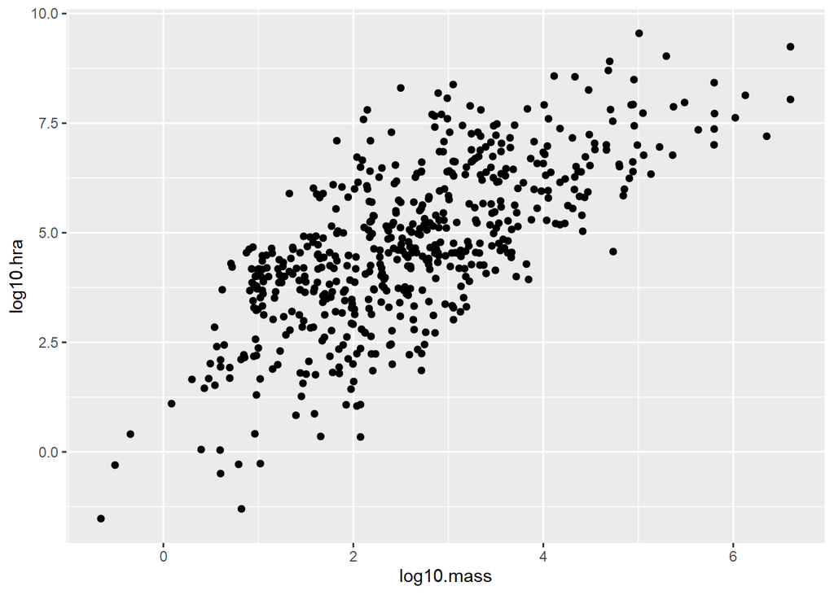

```r
hra |>
  ggplot2::ggplot(
    ggplot2::aes(x = log10.mass, y = log10.hra)
  ) +
  ggplot2::geom_point()
```

4. Colorize the points in the scatterplot by `class_fct`.

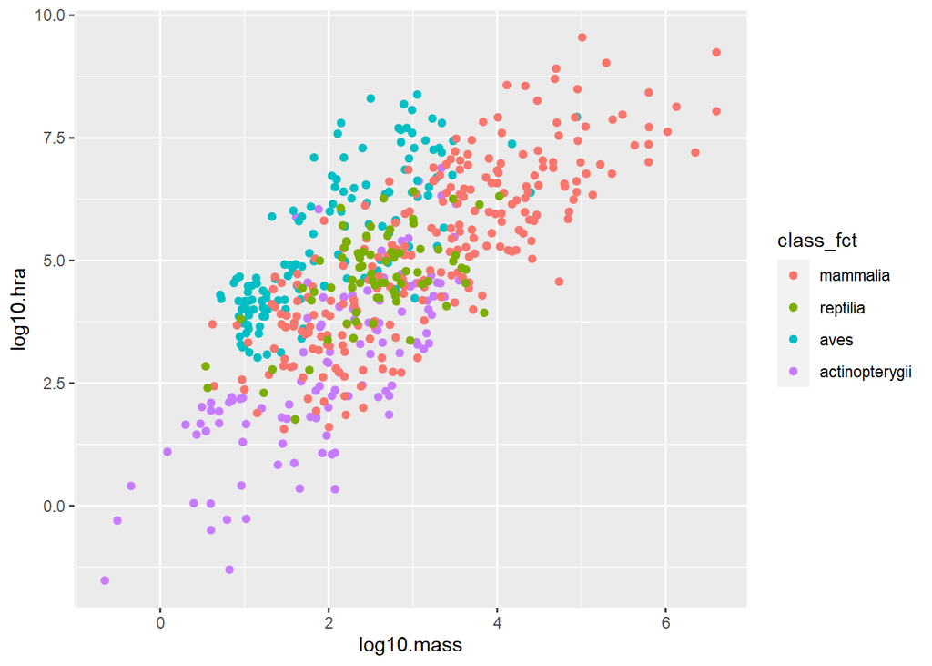

```r
hra |>
  ggplot2::ggplot(
    ggplot2::aes(x = log10.mass, y = log10.hra, color = class_fct)
  ) +
  ggplot2::geom_point()
```

5. Display a scatterplot showing only data for birds (class `aves`) and fit a linear regression to that data using the `lm` function.

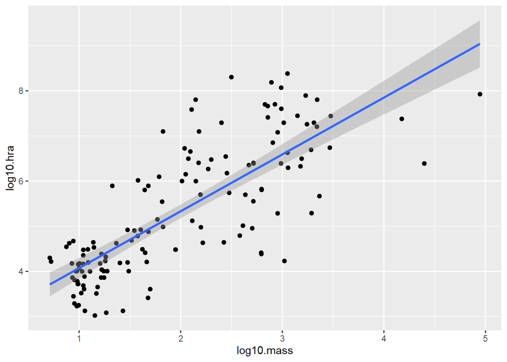

```r
hra |>
  dplyr::filter(class == "aves") |>
  ggplot2::ggplot(
    ggplot2::aes(x = log10.mass, y = log10.hra)
  ) +
  ggplot2::geom_point() +
  ggplot2::geom_smooth(method = "lm")
```

### Functional Programming

1. Write a function called `summarize_table` that takes a title string and a tibble as input and returns a string that says something like, “*title* has *#* rows and *#* columns”. For example, `summarize_table('our table', person)` should return the string `"our table has 5 rows and 3 columns"`.

```r
summarize_table <- function(title, .data) {
  nrow <- nrow(.data)
  ncol <- ncol(.data)

  glue::glue("{title} has {nrow} rows and {ncol} cols")
}

summarize_table("iris", iris)
```

```
## iris has 150 rows and 5 cols
```

2. Write another function called `show_columns` that takes a string and a tibble as input and returns a string that says something like, “*table* has columns *name*, *name*, *name*”. For example, `show_columns('person', person)` should return the string `"person has columns person_id, personal_name, family_name"`.

```r
show_columns <- function(title, .data) {
  cols <- paste(colnames(.data), collapse = ", ")

  return(glue::glue("{title} has columns {cols}"))
}

show_columns("iris", iris)
```

```
## iris has columns Sepal.Length, Sepal.Width, Petal.Length, Petal.Width, Species
```

3. The function `rows_from_file` returns the first *N* rows from a table in a CSV file given the file’s name and the number of rows desired. Modify it so that if no value is specified for the number of rows, a default of 3 is used.

```r
rows_from_file <- function(filename, num_rows = 3) {
  readr::read_csv(filename) %>% head(n = num_rows)
}

rows_from_file("measurements.csv") # should show 3 rows
```

4. The function `long_name` checks whether a string is longer than 4 characters. Use this function and a function from `purrr` to create a logical vector that contains the value `TRUE` where family names in the tibble `person` are longer than 4 characters, and `FALSE` where they are 4 characters or less.

```r
long_name <- function(name) {
  stringr::str_length(name) > 4
}

person |>
  mutate(long_family_name = map_lgl(family_name, long_name))
```

### Wrapping Up

1. Modify the YAML header of this file so that a table of contents is automatically created each time this document is knit, and fix any errors that are preventing the document from knitting cleanly.

```
---
title: "Tidyverse Exam Verson 2.0"
output:
html_document:
    theme: flatly
    toc:true
---
```